# Reproducible Research Project Week2

Aditya Pradana

January 19, 2017

## R Markdown

This is an R markdown document for Coursera Project in Reproducible Research module in Week 2. This markdown will show the codes to answer the questions in the assignment.

### Loading and preprocessing the data

Below is the code to load data into R and process it. This is assuming that the dataset file **activity.csv** is in the same folder with R Markdown document. Otherwise, download the data from this link (https://d396qusza40orc.cloudfront.net/repdata%2Fdata%2Factivity.zip).  
Preprocess the data. Convert factor to strings. Convert date string to Date class.

```r
activity <- read.csv("activity.csv", header=TRUE, stringsAsFactors = FALSE)
activity$date <- as.Date(as.character(activity$date), "%Y-%m-%d")
head(activity)
```

```
##   steps       date interval
## 1    NA 2012-10-01        0
## 2    NA 2012-10-01        5
## 3    NA 2012-10-01       10
## 4    NA 2012-10-01       15
## 5    NA 2012-10-01       20
## 6    NA 2012-10-01       25
```

### What is mean total number of steps taken per day?

**1. Total number of steps per day**  
The code below sum the steps, remove NA, group them by date, and name the column in the resulting dataset.

```r
totalsteps <- setNames(aggregate(activity$steps, by=list(activity$date),
                                  FUN=sum, na.rm=TRUE),
                                    c("Date", "Steps"))
```

**2. Histogram**  
Code below draws histogram of frequency of total steps and save the plot under ~/figure/ folder.

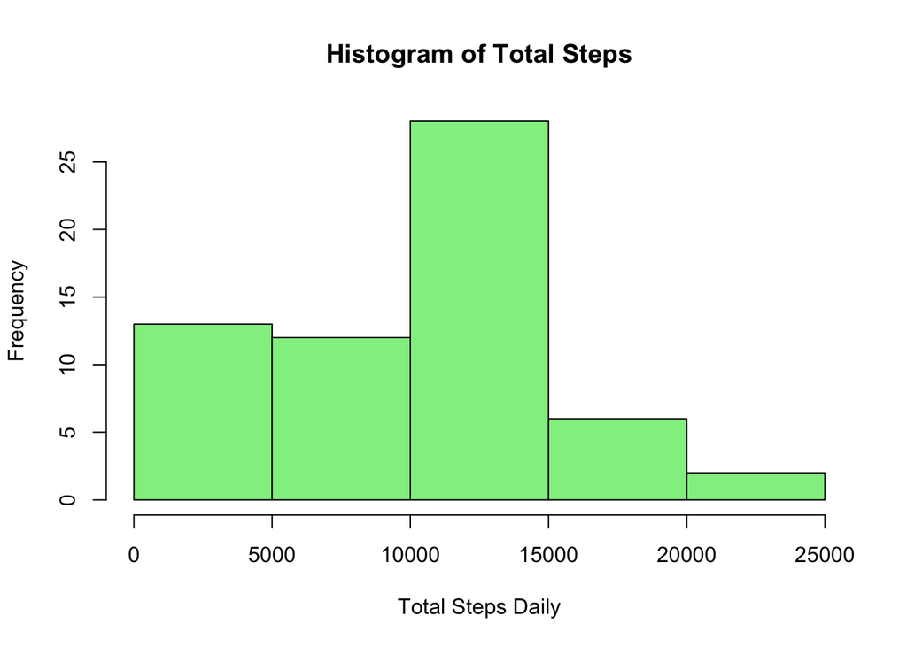

```r
hist(totalsteps$Steps,
     xlab="Total Steps Daily", ylab="Frequency", main="Histogram of Total Steps",
     col="light green")
```

**3. Mean & Median**  
Calculate Mean and Median

```r
##Mean
mean(totalsteps$Steps)
```

```
## [1] 9354.23
```

```r
##Median
median(totalsteps$Steps)
```

```
## [1] 10395
```

### What is the average daily activity pattern?

**1. Time series plot**  
Create a dataframe of average steps daily versus interval.  
Name the dataframe column and create the plot.

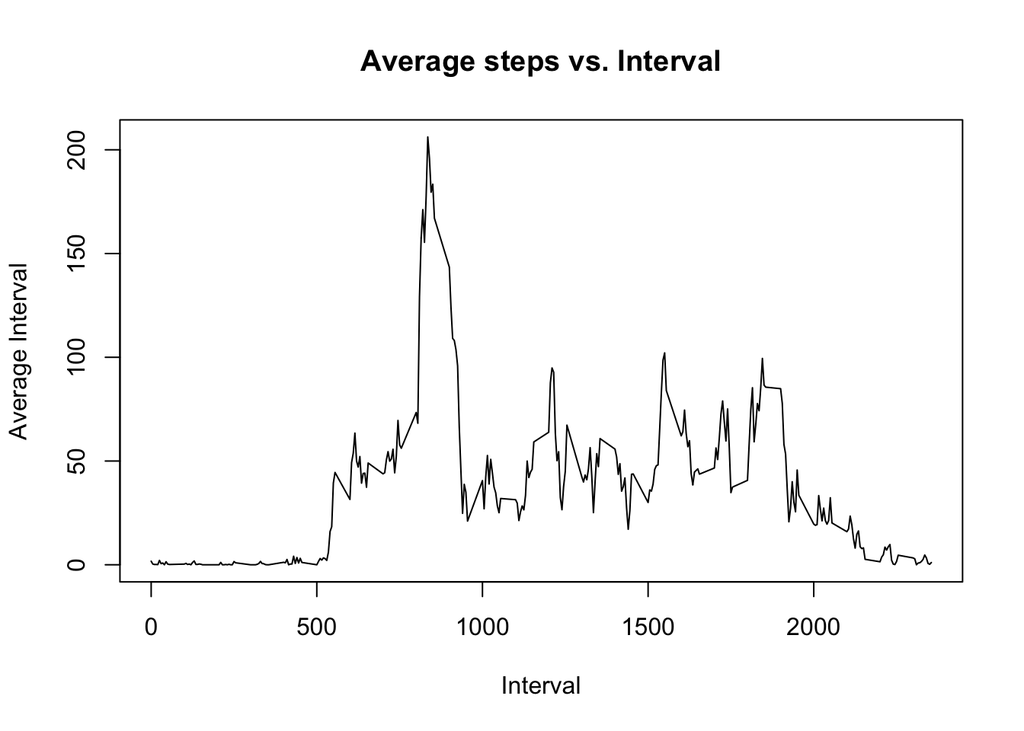

```r
avginterval <- setNames(aggregate(activity$steps, by=list(activity$interval),
                         FUN=mean, na.rm=TRUE), c("Interval", "Average.Steps"))
plot(x=avginterval$Interval, y=avginterval$Average.Steps,
     xlab="Interval", ylab="Average Interval", main="Average steps vs. Interval",
     type="l")
```

**2. Which 5-min interval contains maximum no. of steps**

```r
avginterval[avginterval$Average.Steps==max(avginterval$Average.Steps),]
```

```
##     Interval Average.Steps
## 104      835      206.1698
```

We can see that the maximum no. of steps is at interval **835min**.